# report_editable_api

Quick Scan

Engagement průzkum

Manažerský výstup

Co nás dnes čeká

- 01Průzkum v číslech
- 02Výsledky engagementu
- 03Výsledky jednotlivých driverů
- 04Otevřené otázky
- 05Co dělat s výsledky
- 06Doprovodné grafy

01

Průzkum v číslech

Tato sekce poskytuje základní přehled o průběhu průzkumu ve firmě. Ukážeme Vám např. kolik zaměstnanců se průzkumu zúčastnilo celkově, za jednotlivé organizační jednotky nebo podle demografických údajů.

Průzkum v číslech

17 lidí

ve vaší firmě odpovědělo na průzkum.

Respondenti podle oddělení

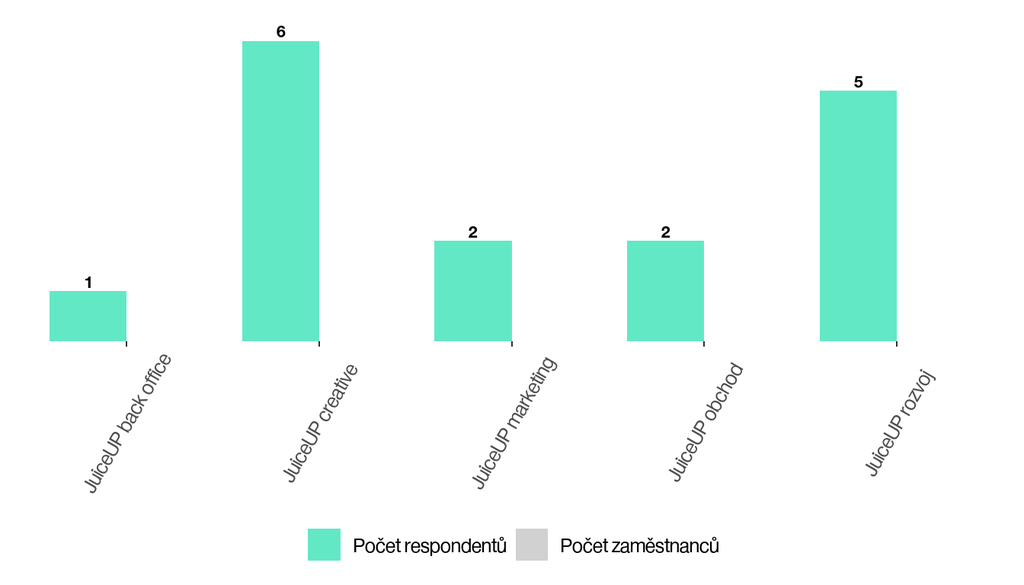

Respondenti podle věku

[figure not shown]

Pracovní pozice

[figure not shown]

Délka působení ve firmě

[figure not shown]

02

Výsledky engagementu

Engagement popisuje vztahy uvnitř firmy. Vztahy mezi zaměstnanci navzájem nebo zaměstnanců k jejich práci. Vyjadřuje, jak moc se člověk dokáže do své práce ponořit, jak pro svou práci/ firmu/kolegy udělá o krok navíc či jednoduše, jak moc jej práce baví a těší.

Engagement je komplexní téma. Právě proto jej měřímě pomocí dvou rozdílných metrik – Engagement indexu a Individuální míry engagementu. Výpočet obou metrik Vám dále vysvětlíme a odprezentujeme.

Metriky engagementu

Jedna metrika vám ukáže, jak dobře vycházejí jednotlivé oblasti engagementu. Druhá vám ukáže, kolik lidí je skutečně zapojených. Teprve kombinace obou pohledů dává smysl. Může se stát, že celkové skóre nevypadá špatně, ale ve skutečnosti jen menší část lidí je opravdu plně zapojená. Nebo naopak – lidé mají silný vztah ke své práci, ale slabší k zaměstnavateli. Použití obou metrik je proto důležitý „double check“. Pomáhá odhalit nerovnováhu a dává přesnější základ pro rozhodování

01

Engagement index

Engagement index ukazuje, jak silně vycházejí jednotlivé oblasti engagementu napříč firmou. Sleduje podíl nejvíce pozitivních odpovědí u čtyř klíčových otázek – dvou zaměřených na vztah k práci a dvou na vztah k zaměstnavateli. Nezaměřuje se na jednotlivce, ale na celkový obraz. Odpovídá na otázku: Jak si stojíme jako firma v oblastech, které tvoří engagement?

02

Individuální míra engagementu

Individuální míra engagementu se dívá na každého respondenta zvlášť. Podle kombinace jeho odpovědí určuje, zda patří mezi plně zapojené, částečně zapojené nebo odpojené zaměstnance. Výsledkem je jasný přehled o tom, kolik lidí je skutečně „na palubě“ a kolik je jen částečně nebo vůbec. Odpovídá na otázku: Kolik lidí je opravdu zapojených – a kolik ne?

Jak číst?

Engagement index

?

?

?

Engagement index ukazuje, jak silně vycházejí klíčové oblasti engagementu napříč firmou. Sleduje podíl nejvíce pozitivních odpovědí u čtyř základních otázek – dvou ke vztahu k práci a dvou ke vztahu k zaměstnavateli. Nehodnotí jednotlivce, ale celkový obraz firmy. Pomáhá rychle pochopit, jak pevný je základ engagementu.

Engagement index za firmu

Úplný engagement

42 %

Úplný engagement za firmu = 42 %. To znamená, že 42 % **odpovědí na všechny engagementové otázky bylo Určitě ano.**

Částečný engagement

33 %

Částečný engagement za firmu = 33 %. To znamená, že 33 % **odpovědí na všechny engagementové otázky bylo Spíše ano nebo Nemohu se rozhodnout.**

Slabý engagement

25 %

Slabý engagement za firmu = 25 %. To znamená, že 25 % **odpovědí na všechny engagementové otázky bylo Spíše ne nebo Určitě ne.**

Engagement index se měří následujícími otázkami:

Jsem spokojený/á s náplní své práce.

Má práce mě baví.

Moje práce mi dává smysl.

Jsem hrdý/á na práci, kterou ve firmě dělám.

Škála odpovědí

Určitě ano

Spíše ano

Nemohu se rozhodnout

Spíše ne

Určitě ne

Jak číst?

Individuální míra engagementu

?

?

?

Individuální míra engagementu ukazuje, kolik lidí ve firmě je skutečně plně zapojených, kolik je zapojených částečně a kolik je odpojených. Každý zaměstnanec je zařazen podle kombinace svých odpovědí na čtyři engagementové otázky. Výsledkem je jasná struktura firmy podle míry zapojení lidí. Tato metrika odpovídá na otázku: Kolik lidí je opravdu „na palubě“?

Individuální míra engagementu

Engaged

42 %

42 % engaged zaměstnanců = kolik % zaměstnanců spadá do kategorie engaged. Engaged zaměstnanec je každý, kdo má průměrné skóre engagementových otázek **1,2 a méně.**

Potentials

33 %

33 % potential zamestnancu = kolik % zaměstnanců spadá do kategorie engaged. Engaged zaměstnanec je každý, kdo má pruměrné skóre engagementových otázek **mezi 1,2 a 2,5.**

Disengaged

25 %

25 % disengaged zaměstnanců = kolik % zaměstnanců spadá do kategorie disengaged. Engaged zaměstnanec je každý, kdo má pruměrné skóre engagementových otázek **2,5 a více.**

Příklad:

Respondent odpovědel na engagementové otázky:  
*Určitě ano, Určitě ano, Spíše ano, Spíše ano.*

Jeho/její průměr = (1+1+2+2)/4 = **1,5**  
Respondent patří mezi potenciálně angažované zaměstnance.

Škála odpovědí

Určitě ano = skóre 1

Spíše ano = skóre 2

Nemohu se rozhodnout  
= skóre 3

Spíše ne = skóre 4

Určitě ne = skóre 5

Výsledky

# Engagement index za firmu

v porovnání s benchmarky

Engagement index za firmu

Úplný engagement

47.1 %

Zaměstnanci vykazují silný a konzistentní pozitivní vztah ke své práci i zaměstnavateli. Ve většině odpovědí jasně potvrzují vysokou míru zapojení. Je zde vysoká pravděpodobnost nadstandardního výkonu a ochoty jít nad rámec povinností. Lidé jsou vnitřně motivovaní a firmu vnímají jako správné místo pro sebe. Tato úroveň vytváří stabilní základ pro výkon i dlouhodobou loajalitu.

Částečný engagement

51.5 %

Zaměstnanci jsou zapojení, ale jejich vztah k práci nebo firmě není plně stabilní. V některých oblastech fungují velmi dobře, jinde je viditelná nejistota nebo rezervy. Výkon bývá solidní, ale nemusí být dlouhodobě udržitelný bez další podpory. Tato skupina je citlivá na změny prostředí a kvalitu vedení. Při správném zaměření rozvoje má vysoký potenciál posunout se do plného engagementu.

Slabý engagement

1.5 %

Zaměstnanci vykazují nízkou míru pozitivního vztahu k práci nebo zaměstnavateli.Objevuje se odstup, nižší motivace nebo minimální ochota investovat energii navíc.Výkon může být kolísavý nebo čistě „na nutné minimum“. Rizikem je vyšší fluktuace nebo negativní vliv na týmové prostředí. Tato úroveň vyžaduje rychlou pozornost a cílené manažerské zásahy.

Benchmarky:

33 %

Česká republika

46 %

USA

32 %

Německo

Škála odpovědí

Určitě ano

Spíše ano

Nemohu se rozhodnout

Spíše ne

Určitě ne

Výsledky

# Engagement index za firmu

Engagement se měřil následujícími otázkami:

První dvě engagementové otázky se zaměřují na vztah zaměstnance k jeho vlastní práci. Sledují, zda lidé vnímají svou práci jako smysluplnou, motivující a zda jsou ochotni do ní investovat energii navíc. Tato oblast ukazuje osobní zapojení do každodenního výkonu. Pokud je zde skóre vysoké, lidé chtějí svou práci dělat dobře bez ohledu na okolnosti. Pokud je nízké, problém se týká samotné náplně práce, role nebo vnitřní motivace.

[figure not shown]

Druhé dvě engagementové otázky se zaměřují na vztah zaměstnance k firmě jako zaměstnavateli. Sledují míru důvěry, sounáležitosti a ochotu spojit s organizací svou budoucnost. Tato oblast ukazuje, zda lidé stojí za firmou jako celkem – nejen za svou vlastní prací. Vysoké skóre znamená silnou loajalitu a identifikaci s firmou. Nízké skóre naopak signalizuje riziko odchodu nebo vnitřního odstupu, i když samotná práce může zaměstnance bavit.

[figure not shown]

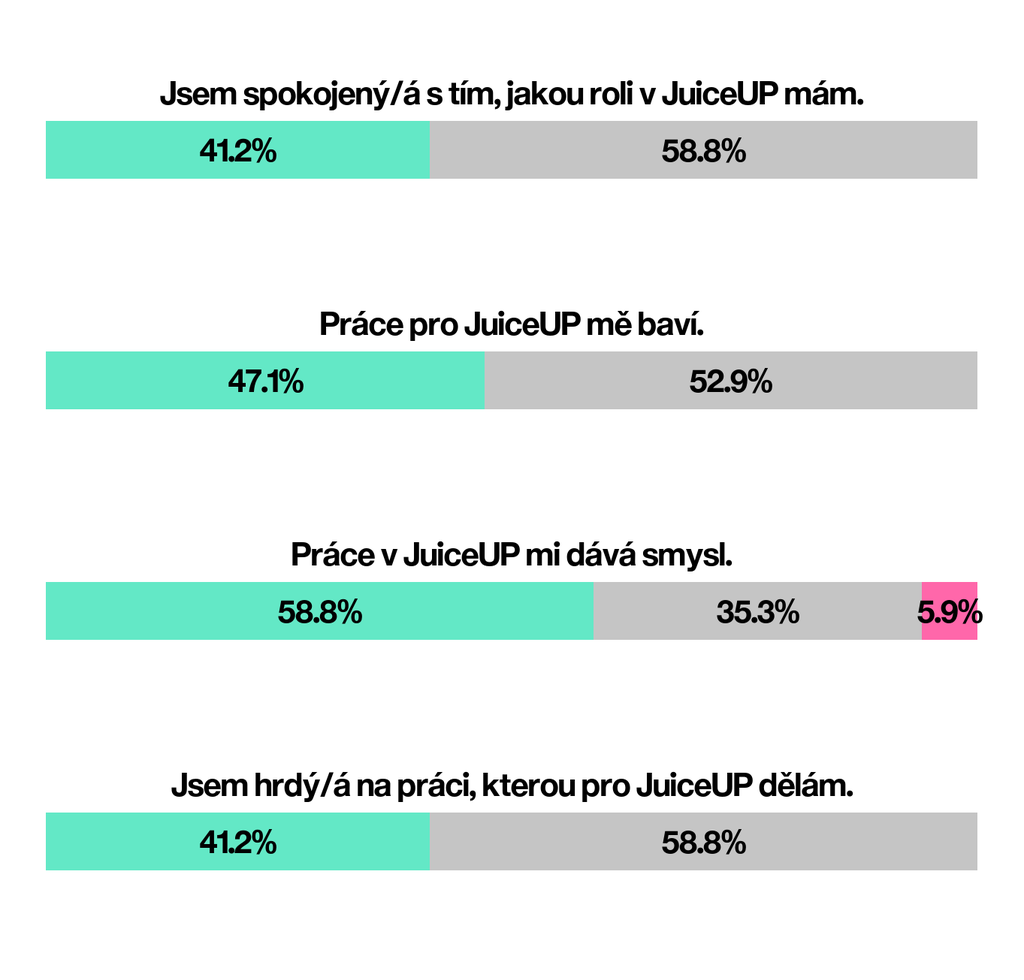

Škála odpovědí

Určitě ano

Spíše ano

Nemohu se rozhodnout

Spíše ne

Určitě ne

Výsledky

# Individuální míra engagementu za firmu

Individuální míra engagementu za firmu

Engaged

17.6 %

Tito zaměstnanci mají silný vztah ke své práci i k zaměstnavateli. Cítí smysl v tom, co dělají, a firmu vnímají jako správné místo pro sebe. Jsou ochotni investovat energii navíc a přirozeně podporují výkon týmu. Často působí jako stabilizační prvek v náročnějších obdobích. Představují klíčovou skupinu pro dlouhodobý úspěch organizace.

Potentials

82.4 %

Tito zaměstnanci nejsou odpojení, ale jejich vztah není plně pevný. Mohou být spokojeni s prací, ale méně s firmou – nebo naopak. Jejich výkon bývá stabilní, ale bez výrazného nadšení. Jsou citlivější na změny, styl vedení nebo pracovní podmínky. Při správné práci s nimi mají vysoký potenciál posunout se do plného engagementu.

Disengaged

0 %

Tito zaměstnanci vykazují nízkou míru zapojení k práci, firmě nebo oběma oblastem. Často fungují pouze na úrovni základních povinností. Může se objevovat frustrace, odstup nebo nedůvěra. Je zde vyšší riziko poklesu výkonu nebo odchodu z organizace. Tato skupina vyžaduje rychlé porozumění příčinám a cílený zásah.

Škála odpovědí

Určitě ano = skóre 1

Spíše ano = skóre 2

Nemohu se rozhodnout  
= skóre 3

Spíše ne = skóre 4

Určitě ne = skóre 5

Výsledky

# Srovnání engagement indexu napříč odděleními

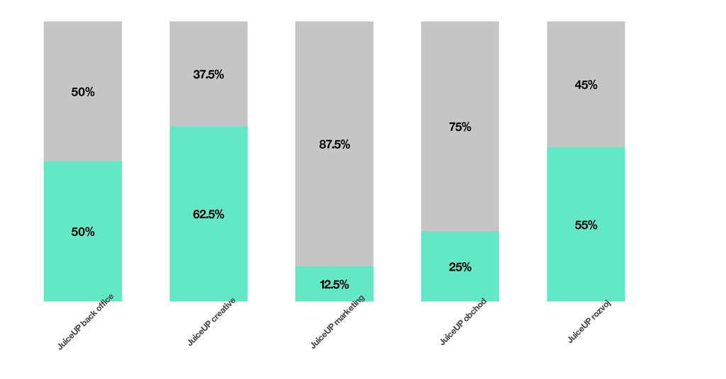

Škála odpovědí

Určitě ano

Spíše ano

Nemohu se rozhodnout

Spíše ne

Určitě ne

Výsledky

# Srovnání individuální míry engagementu napříč odděleními

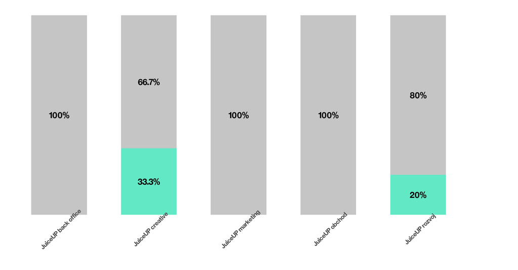

Škála odpovědí

Určitě ano = skóre 1

Spíše ano = skóre 2

Nemohu se rozhodnout  
= skóre 3

Spíše ne = skóre 4

Určitě ne = skóre 5

03

Výsledky klíčových driverů

Engagement neexistuje ve vakuu. Výsledky engagementu mohou být značně ovlivněny různými klíčovými tématy, tzv. drivery engagementu. Moduly zařazené do průzkumu jsou aktuálními daty podložené významné drivery engagementu.

Měřené/sledované drivery

Diky neustálému sledování trendů v oblasti engagementu a analýze našich dat jsme vybrali moduly, které jsou podle nás nejvýznamnějšími drivery engagementu. Pojďme si je teď podrobněji představit

Já a tým

Tento driver hodnotí kvalitu spolupráce a vztahů uvnitř týmu nebo oddělení. Sleduje vzájemnou důvěru, otevřenost při řešení chyb a schopnost hledat taková řešení, aby se problémy neopakovaly. Zahrnuje také srozumitelnost týmových cílů a prostor pro zapojení nápadů zaměstnanců. Ukazuje, zda tým funguje jako bezpečné a spolupracující prostředí. Nízké skóre může znamenat slabou důvěru, nejasné cíle nebo omezenou možnost ovlivňovat fungování týmu.

Já a vedoucí

Tento driver hodnotí kvalitu vztahu mezi zaměstnancem a jeho přímým nadřízeným. Sleduje důvěru, podporu, otevřenost a schopnost vedoucího dávat směr. Zahrnuje také férovost rozhodování a schopnost řešit problémy. Ukazuje, zda vedení posiluje motivaci a stabilitu týmu. Nízké skóre může znamenat slabou komunikaci, nedostatek podpory nebo nejistotu v řízení.

Já a práce

Tento driver se zaměřuje na to, jak zaměstnanec vnímá svou každodenní práci. Sleduje, zda má dostatek zdrojů, jasné procesy a podmínky pro kvalitní výkon. Zahrnuje také míru samostatnosti, iniciativy a možnosti ovlivnit své pracovní prostředí. Ukazuje, zda práce dává smysl a umožňuje lidem být efektivní. Nízké skóre často signalizuje překážky v systému, nejasné role nebo nedostatek podpory

Měřené/sledované drivery

Diky neustálému sledování trendů v oblasti engagementu a analýze našich dat jsme vybrali moduly, které jsou podle nás nejvýznamnějšími drivery engagementu. Pojďme si je teď podrobněji představit

Já a rozvoj

Tento driver se zaměřuje na možnosti růstu a učení. Sleduje, zda mají zaměstnanci příležitost rozvíjet své dovednosti a posouvat se dál. Zahrnuje kvalitu zpětné vazby, podporu rozvoje i jasnost kariérních možností. Ukazuje, zda lidé vidí ve firmě perspektivu. Nízké skóre může znamenat stagnaci, nejasné očekávání nebo nedostatek podpory v růstu.

Já a firma

Tento driver sleduje vztah zaměstnance k organizaci jako celku. Zahrnuje důvěru ve směřování firmy, srozumitelnost cílů a kvalitu interní komunikace. Zaměřuje se také na hodnoty a míru sounáležitosti. Ukazuje, zda lidé firmě věří a chtějí s ní spojit svou budoucnost. Nízké skóre může naznačovat nejistotu, slabou komunikaci nebo oslabenou loajalitu.

Já a interní komunikace

Já a bezpečnost

Tento driver hodnotí vnímání bezpečnosti při výkonu práce. Sleduje, zda zaměstnanci rozumí bezpečnostním předpisům, mají potřebné informace a vědí, jak postupovat při hlášení rizik nebo incidentů. Zahrnuje také dostupnost vhodných prostředků a podmínek pro bezpečnou práci. Ukazuje, zda je bezpečnost ve firmě brána vážně a zda lidé dodržování pravidel skutečně podporují. Nízké skóre může znamenat nedostatečnou informovanost, chybějící prostředky nebo slabou bezpečnostní kulturu.

Prezentace driverů

Data z driverů prezentujeme na čtyřech úrovních detailu, od **obecných souhrnů až po podrobné analýzy.**

**První dvě úrovně** **(Obecný souhrn)** se zaměřují na odpovědi agregované do širších kategorií (skvělý, průměrný, slabý výsledek). Agregované odpovědi nejprve porovnáme s externími benchmarky a poté zmapujeme situaci uvnitř firmy.

**Další dvě úrovně** **(Podrobné analýzy)** se zaměřují na detailní rozložení odpovědí. Na třetí úrovni uvidíte procentuální podíl odpovědí na každou otázku – od „Určitě ano“ po „Určitě ne“ – na úrovni celé firmy. Čtvrtá úroveň pak ukáže, jak se odpovědi rozdělují mezi jednotlivé organizační jednotky.S každým krokem získáte hlubší přehled o dění ve firmě.

Obecný souhrn

Podrobné analýzy

Agregace:

**Skvělý výsledek** = Určitě ano a Spíše ano,  
**Průměrný výsledek** = Nemohu se rozhodnout,  
**Slabý výsledek** = Určitě ne, Spíše ne

Agregace:

Urcite ano - Spise ano - Nemohu se rozhodnout - Spise ne - Urcite ne  
**Každá hodnota je sledována samostatně**

1.

**Srovnání s benchmarky**

2.

**Celkový přehled za firmu**

3.

**Detail otázek**

4.

**Drivery v detailu za organizační jednotku**

Jak číst?

Srovnání driverů s relevantními benchmarky

?

?

?

V této fázi sledujeme pouze podíl odpovědí, které klasifikujeme jako **skvělý výsledek** na všech odpovědích v rámci daného driveru.To nám umožňuje podívat se na výsledky s odstupem a srovnat je s relevantními benchmarky, než se plně ponoříme do rozboru výsledků uvnitř firmy.

**Příklad:** driver Já a firma zde má hodnotu 81 %. To znamená, že 81 % odpovědí na otázky u tohoto driveru bylo buď **Určitě ano** nebo **Spíše ano.**

Aktuální průzkum

Benchmark 1

Benchmark 2

Já a firma

81 %

78 %

88 %

Já a práce

78 %

98 %

78 %

Já a vedoucí

87 %

63 %

78 %

Já a rozvoj

67 %

88 %

76 %

Jak číst?

Vysledky driveru za firmu

?

?

?

Tento pohled na drivery engagementu je klíčový a z manažerského pohledu i nejvíce informativní. Na jednu stranu ukazuje kompletní agregované výsledky všech driverů (tzn. skvělé, průměrné i špatné výsledky), ale zároveň shrnuje i skvělé výsledky pro každou z otázek. Nabízí tak optimální balanc mezi celkovým přehledem a detailními výsledky.

**15 %**

Podíl odpovědí **Určitě ano**  
a **Spíše ano** na všech odpovedich driveru

**75 %**

Podíl odpovědí **Nemohu se rozhodnout** na všech odpovědích driveru

**10 %**

Podíl odpovědí **Určitě ne**  
a **Spíše ne** na všech odpovědich driveru

Podíl odpovědí **Určitě ano a Spíše ano**  
na všech odpovědích na danou otázku

88 % Můj vedoucí mi zadává úkoly jasně a přesně.

88 % Mám dobrý vztah se svým vedoucím.

88 % Dostávám pravidelnou zpětnou vazbu od mého vedoucího.

88 % Můj vedoucí mě dostatečně motivuje v mé práci.

Škála odpovědí

Určitě ano

Spíše ano

Nemohu se rozhodnout

Spíše ne

Určitě ne

Jak číst?

Detail otázky

?

?

?

Detailní rozpad otázek jednoduše znamená, že pro každou otázku uvidíte, jaký měla podíl jednotlivých možných odpovědí. Tento podrobný pohled dokáže zodpovědět i velmi konkrétní otázky a přináší hluboký vhled do spokojenosti zaměstnanců v určitých tématech.

Otázka 1

**20 %**

**20 %**

**20 %**

**20 %**

**20 %**

Otázka 2

**20 %**

**20 %**

**20 %**

**20 %**

**20 %**

Podíl odpovědi **Určitě ano** na danou otázku

Podíl odpovědi **Spíše ano** na danou otázku

Podíl odpovědi **Nemohu se rozhodnout** na danou otázku

Podíl odpovědi **Spise ne** na danou otázku

Podíl odpovědi **Určitě ne** na danou otázku

Škála odpovědí

Určitě ano

Spíše ano

Nemohu se rozhodnout

Spíše ne

Určitě ne

Výsledky

Srovnání driverů s relevantními benchmarky

Aktualni pruzkum

Česká republika

Já a tým

**95 %**

**77 %**

Já a vedoucí

**92 %**

**73 %**

Já a rozvoj

**78 %**

**60 %**

Já a firma

**75 %**

**75 %**

Já a výkon

**57 %**

**85 %**

Výsledky

Drivery za firmu

Top 3

Bottom 3

Já a tým

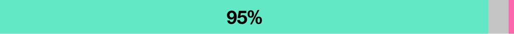

100 %Lidé, se kterými nejčastěji spolupracuji, si důvěřují a mohou se na sebe spolehnout.

100 %Mám možnost přicházet s nápady a návrhy na zlepšení naší práce.

100 %O chybách se umíme bavit tak, aby z toho vzniklo poučení, ne hledání viníka.

100 %Vím, na koho se můžu obrátit, když potřebuji pomoc, informaci nebo rozhodnutí.

94 %V JuiceUP je bezpečné mluvit i o tom, co se nedaří nebo co nefunguje.

76 %V JuiceUP otevřeně řešíme problémy, které se v práci objevují.

Já a vedoucí

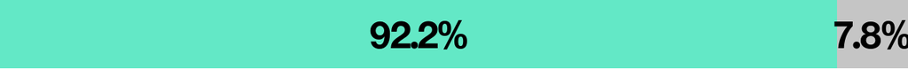

100 %Důvěřuji svému vedoucímu.

100 %Můj vedoucí mi zadává práci srozumitelně a jasně.

100 %Můj vedoucí se zajímá o můj názor a bere ho v úvahu.

88 %Mám jasno v tom, co se ode mě v práci očekává.

82 %Dostávám dostatek zpětné vazby k tomu, co dělám dobře a co mohu zlepšit.

82 %Můj vedoucí podporuje můj profesní rozvoj.

Směřování JuiceUP

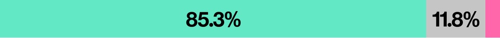

100 %Věřím tomu, že JuiceUP má potenciál stát se jedním z nejsilnějších hráčů ve své oblasti.

71 %Doporučil/a bych JuiceUP jako zaměstnavatele.

Já a rozvoj

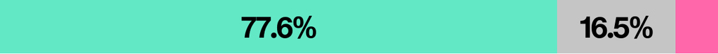

100 %Za dobře odvedenou práci dostávám uznání.

94 %Mám v JuiceUP příležitost učit se nové věci.

76 %Mám dostatek prostoru rozvíjet se ve směru, který dává smysl mně i firmě.

76 %V JuiceUP se přirozeně sdílí zkušenosti, inspirace a know-how.

41 %Dostávám dostatek informací o možnostech rozvoje nebo kariérního posunu v JuiceUP.

Já a firma

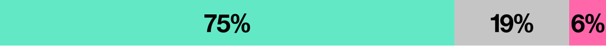

88 %Vím, jak moje práce přispívá k cílům JuiceUP.

82 %Důležité informace o změnách ve firmě se ke mně dostávají včas.

82 %Hodnoty a způsob práce JuiceUP jsou v souladu s tím, jak chci pracovat já.

82 %Rozumím tomu, kam JuiceUP jako firma směřuje.

38 %Komunikace mezi jednotlivými částmi JuiceUP funguje dobře.

Já a výkon

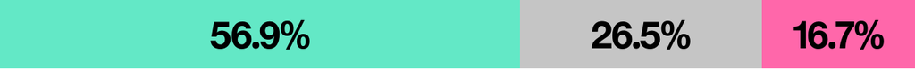

88 %Mám k dispozici zdroje, informace a nástroje, abych mohl/a svou práci dělat dobře.

76 %V mém nejbližším pracovním okruhu je běžné nastavovat si standard kvality a společně ho držet.

65 %Stresová náročnost mé práce v JuiceUP je pro mě dlouhodobě zvládnutelná.

47 %Procesy v JuiceUP mi pomáhají pracovat efektivně.

41 %Mám možnost ovlivnit, jak se nastavují priority mé práce nebo jak se vyhodnocuje její výsledek.

24 %Spolupráce napříč oblastmi mi pomáhá odvádět kvalitní práci pro klienty.

Výsledky

Já a tým - detailně

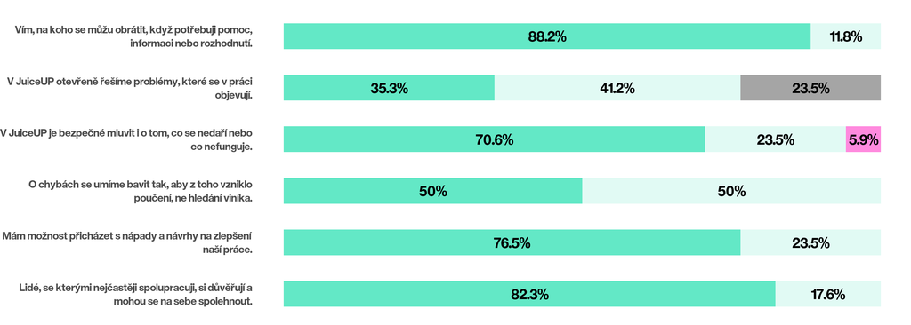

Škála odpovědí

Určitě ano

Spíše ano

Nemohu se rozhodnout

Spíše ne

Určitě ne

Výsledky

Já a vedoucí - detailně

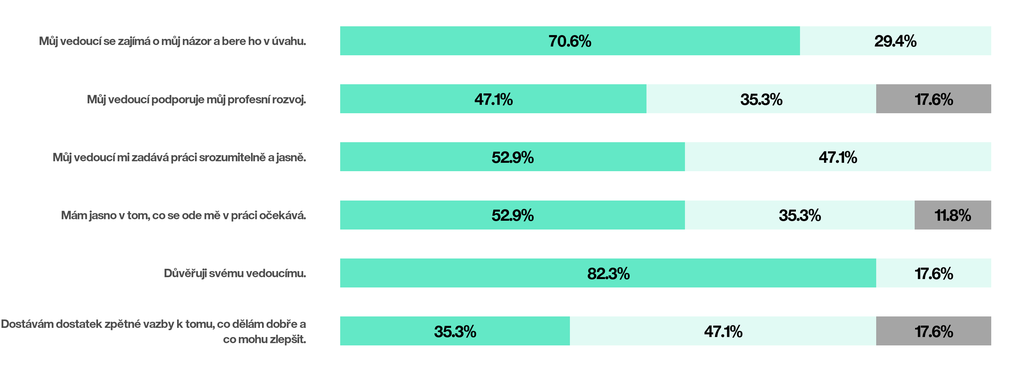

Škála odpovědí

Určitě ano

Spíše ano

Nemohu se rozhodnout

Spíše ne

Určitě ne

Výsledky

Směřování JuiceUP - detailně

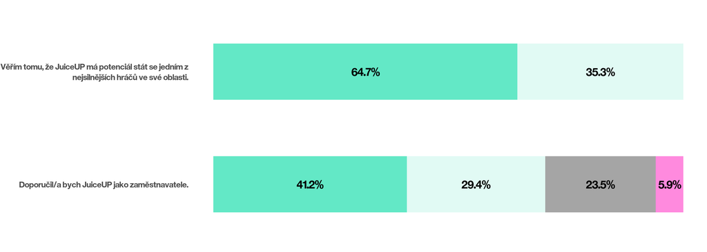

Škála odpovědí

Určitě ano

Spíše ano

Nemohu se rozhodnout

Spíše ne

Určitě ne

Výsledky

Já a rozvoj - detailně

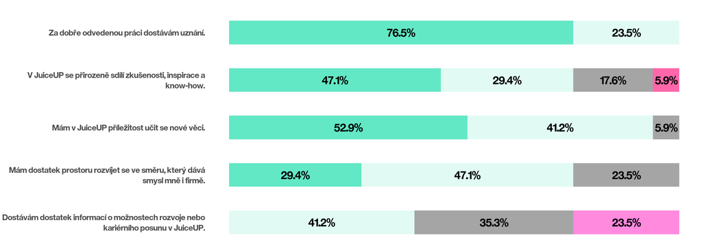

Škála odpovědí

Určitě ano

Spíše ano

Nemohu se rozhodnout

Spíše ne

Určitě ne

Výsledky

Já a firma - detailně

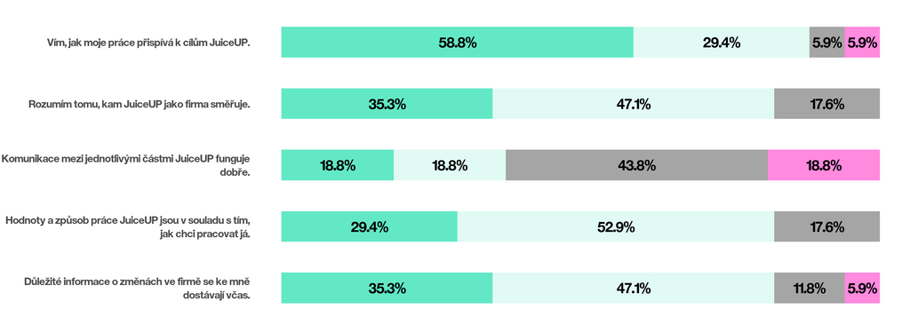

Škála odpovědí

Určitě ano

Spíše ano

Nemohu se rozhodnout

Spíše ne

Určitě ne

Výsledky

Já a výkon - detailně

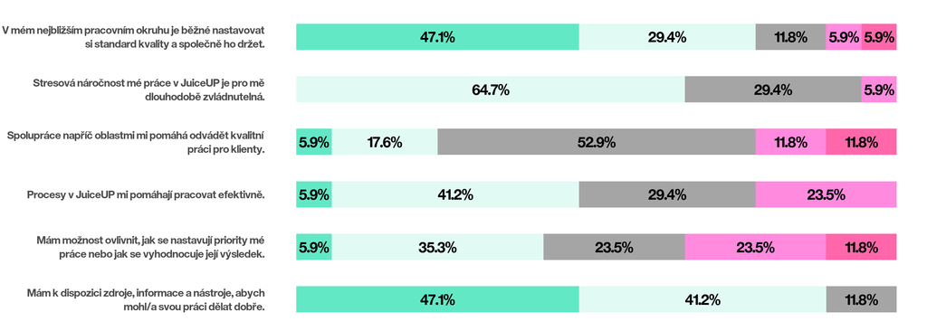

Škála odpovědí

Určitě ano

Spíše ano

Nemohu se rozhodnout

Spíše ne

Určitě ne

Výsledky

Já a tým - Určitě ano srovnání dle oddělení

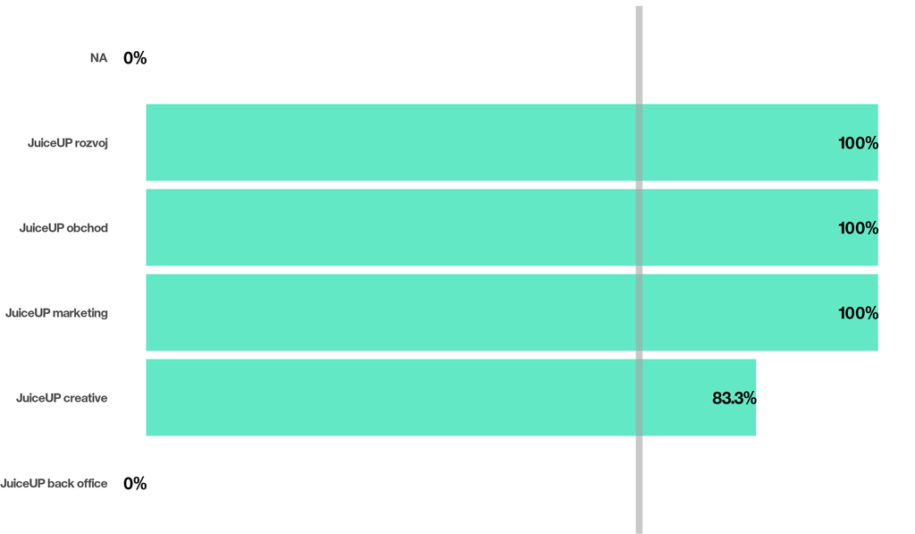

Legenda

Podíl odpovědi za oddělení

Podíl odpovědi za firmu

Výsledky

Já a vedoucí - Určitě ano srovnání dle oddělení

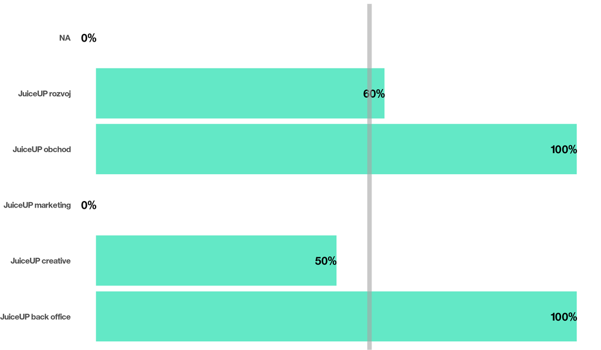

Legenda

Podíl odpovědi za oddělení

Podíl odpovědi za firmu

Výsledky

Směřování JuiceUP - Určitě ano srovnání dle oddělení

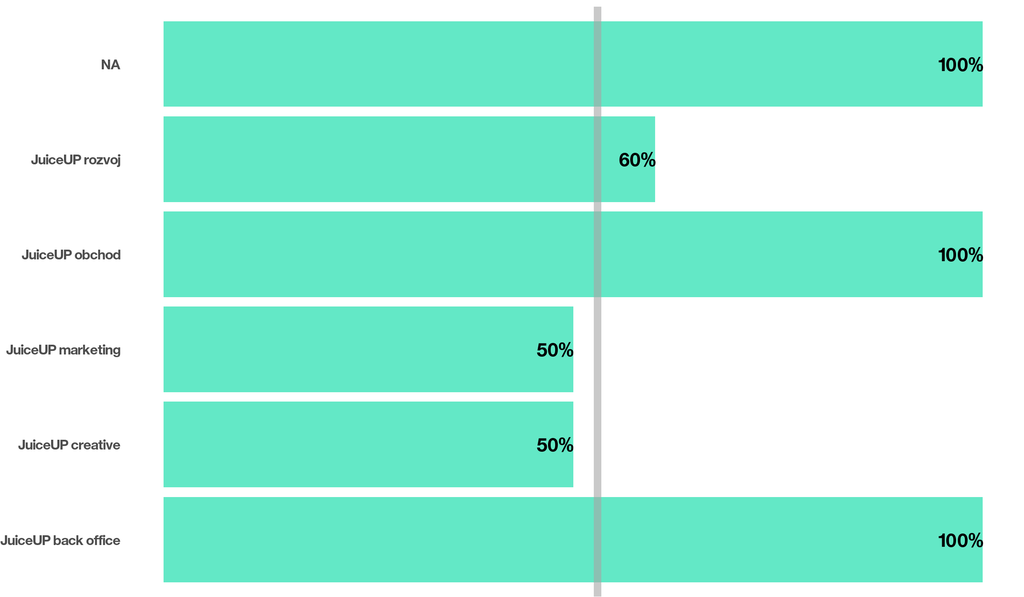

Legenda

Podíl odpovědi za oddělení

Podíl odpovědi za firmu

Výsledky

Já a rozvoj - Určitě ano srovnání dle oddělení

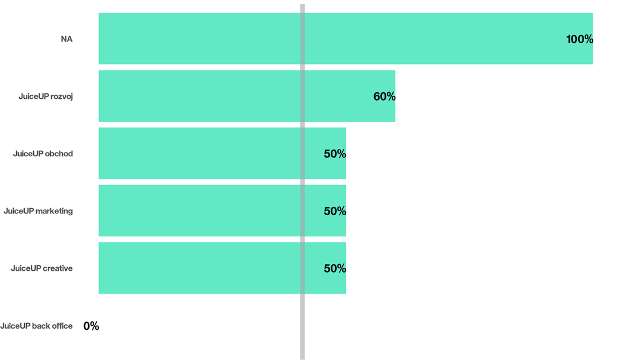

Legenda

Podíl odpovědi za oddělení

Podíl odpovědi za firmu

Výsledky

Já a firma - Určitě ano srovnání dle oddělení

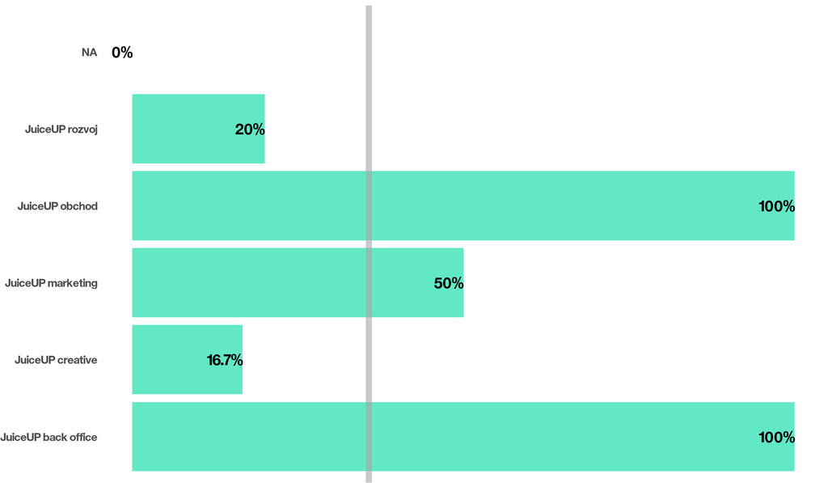

Legenda

Podíl odpovědi za oddělení

Podíl odpovědi za firmu

Výsledky

Já a výkon - Určitě ano srovnání dle oddělení

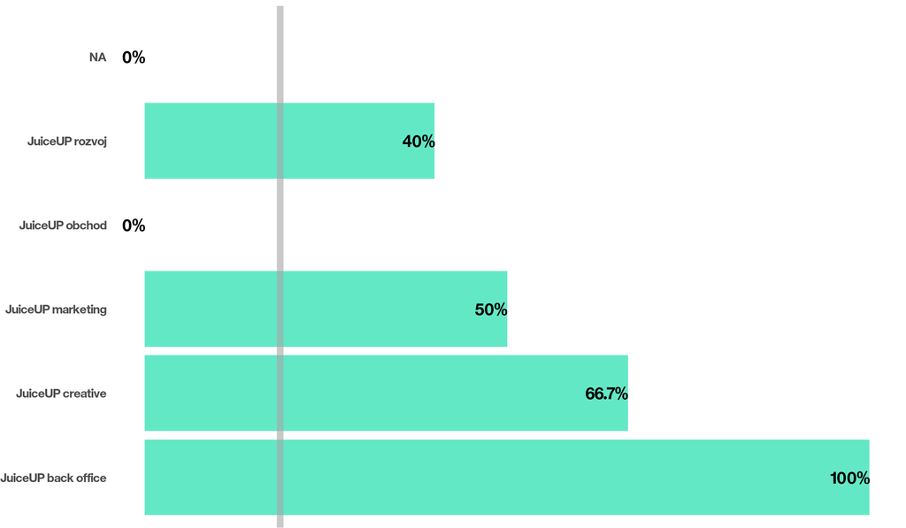

Legenda

Podíl odpovědi za oddělení

Podíl odpovědi za firmu

04

Otevřené otázky

Tato sekce shrnuje odpovědi na otevřené otázky. Odpovědi byly automaticky roztříděny do témat a ke každému tématu byl přiřazen orientační sentiment. Výsledky slouží jako rychlý kvalitativní přehled hlavních motivů v odpovědích.

Výsledky

Co by podle tebe nejvíce pomohlo tomu, aby se ti v JuiceUP pracovalo lépe?

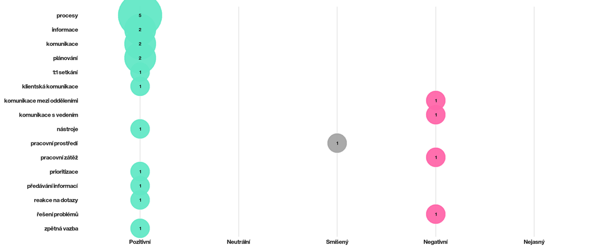

Pozn.: Jedna odpověď může být zařazena do více témat. Velikost bodu odpovídá počtu respondentů.

Výsledky

Co bys chtěl/a founderům vzkázat, aby to v dotazníku nezapadlo?

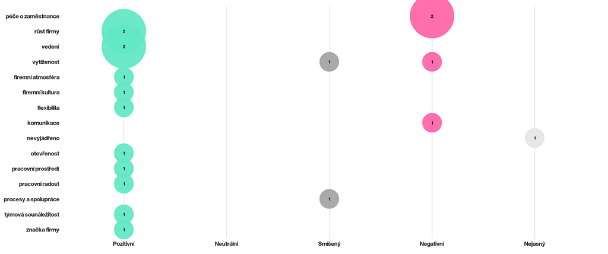

Pozn.: Jedna odpověď může být zařazena do více témat. Velikost bodu odpovídá počtu respondentů.

05

Co dělat s výsledky

Jak interpretovat výsledky a vytvořit z nich smysluplné akce, které vaší firmě/organizaci pomohou?

Ne každé číslo je priorita

Neinterpretujte izolovaná čísla. Výsledek vždy čtěte podle návratnosti, velikosti skupiny, rozdílu vůči benchmarku, rozdílu vůči firmě a aktuální situace organizace.

Návratnost

Výsledky jsou tím silnější, čím lepe odpovídají napříč firmou i jednotlivými skupinami. Návratnost nad 70 % většinou umožňuje komfortní interpretaci, u nižší návratnosti je potřeba více hlídat zastoupení jednotlivých skupin.

Benchmark

Benchmark pomáhá určit kontext. Není to ale rozsudek ani jediný cíl. Predevším je dobré sledovat porovnání s benchmarkem při prvním měření. U dalšího je potom stejně důležité sledovat firemní trend a to, jestli se daří posouvat akčními kroky jednotlivé drivery.

Rozdíl vůči firmě

Tým nebo oddělení může být problémové i tehdy, když celkový výsledek firmy vypadá dobře. Porovnávejte výsledky jednotlivých oddělení/týmů vůči firemnímu benchmarku.

Velikost a proporce skupiny

Stejné procento může znamenat úplně jiný problém podle velikosti firmy nebo týmu. Vždy interpretujte výsledky na základě proporce a velikosti. Dopady špatného vedení ze strany jednoho manazera budou mít zcela jiný dopad ve firmě o velikosti 20 a 500 zaměstnanců.

Aktualní téma firmy

Prioritou se má stát to, co je pro firmu právě teď skutečně důležité: leadership, komunikace, výkon, změna, stabilita, rozvoj nebo spolupráce.

Začněte tím, co už funguje

Dobré výsledky nejsou jen pozitivní část reportu. Ukazují, co ve firmě funguje, co stojí za to chránit a co lze přenést dál.

**Hledejte, co drží firmu silnou:**

1.

Co je nad benchmarkem?

Kde firma dopadla lépe než relevantní srovnání?

2.

Co je nad firemním průměrem?

Které týmy, oddělení nebo skupiny mají výrazně lepší výsledek než zbytek firmy?

3.

Proč to funguje právě tam?

Nestačí říct, že výsledek je dobrý. Důležité je pochopit, jaké chování, návyky, procesy nebo styl vedení k němu vedou.

4.

Jak to komunikovat?

Zaměstnancům jasně řekněte, co dopadlo dobře, poděkujte za otevřenou zpětnou vazbu a pojmenujte konkrétní silné stránky firmy.

5.

Co se daří opakovaně?

Které silné stránky jsou stabilní, nejen jednorázové?

Méně akcí, větší dopad

Cílem průzkumu není porazit benchmark. Cílem je, aby zaměstnanci viděli, že jejich zpětná vazba vede ke konkrétní změně. Stěžejní je vybrat realistický počet aktivit, které firma/organizace může posunout kupředu.

Je výsledek slabý nebo se zhoršuje?

Zajímejte se hlavně o témata, která jsou nízko, klesají nebo se opakovaně vracejí.

Můžeme s tím reálně něco udělat?

Vyberte témata, u kterých lze během dalších měsíců nastavit konkrétní kroky, vlastníka a termín.

Týká se důležité skupiny lidí?

Nejde jen o procenta, ale i o proporci, velikost týmu a dopad na firmu.

Vytvořte pracovní skupinu/skupiny

Vtáhněte do tvorby a řešení akčních kroků na konkrétních odděleních/týmech samotné zástupce ať už z řad vedoucích nebo dedikovaných pracovníků.

Souvisí téma s aktualní situací firmy?

Jinou prioritu bude mít firma v růstu, jinou firma po změně vedení, jinou firma s vysokou fluktuací a jinou firma řešící výkon.

06

Doprovodné grafy

V této závěrečné části najdete doprovodné grafy, které rozšiřují hlavní zjištění reportu a slouží jako podklad pro detailnější interpretaci výsledků.

Výsledky

Já a tým - Spíše ano srovnání dle oddělení

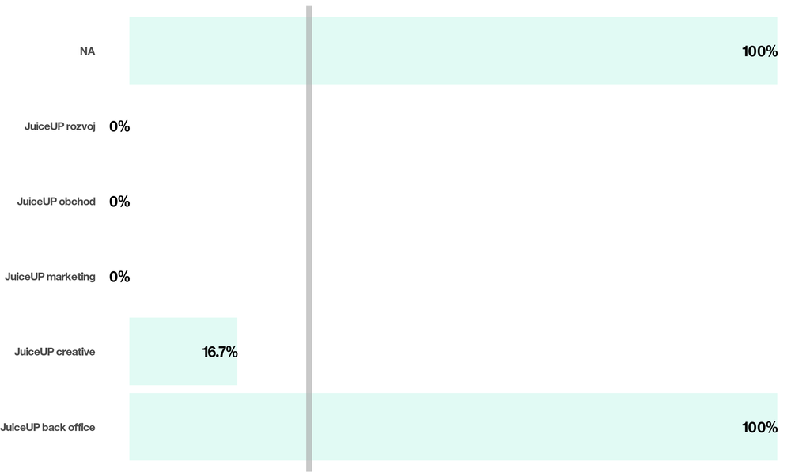

Legenda

Podíl odpovědi za oddělení

Podíl odpovědi za firmu

Výsledky

Já a vedoucí - Spíše ano srovnání dle oddělení

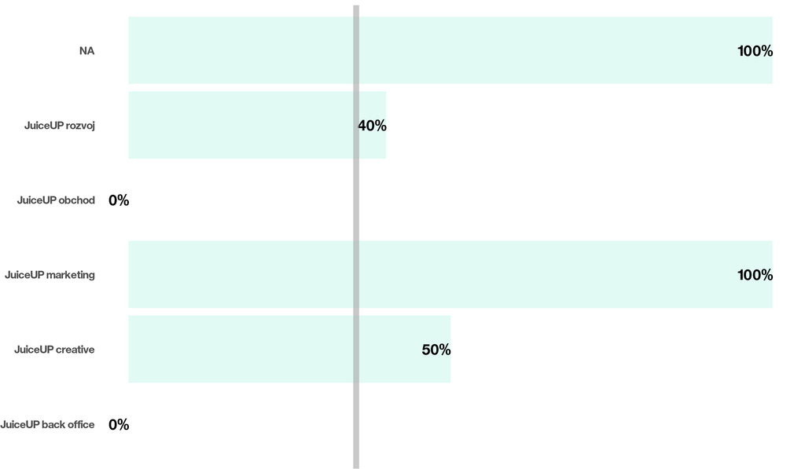

Legenda

Podíl odpovědi za oddělení

Podíl odpovědi za firmu

Výsledky

Směřování JuiceUP - Spíše ano srovnání dle oddělení

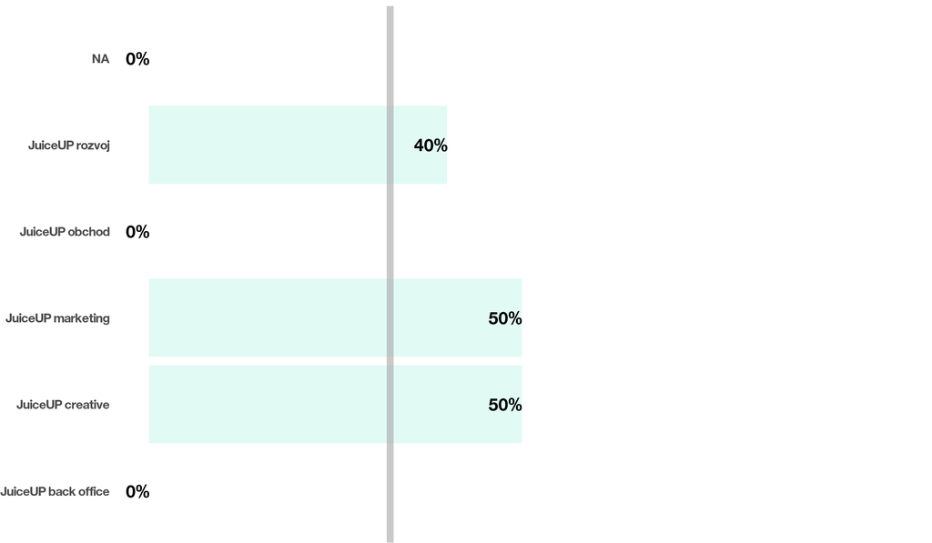

Legenda